# Climate Change 1

Carolina Torreblanca

University of Pennsylvania

**Global Development**: Intermediate Topics in Politics, Policy, and Data

PSCI 3200 - Spring 2026

# Logistics

## Agenda

**Upcoming**

- Wed: Irina
- Next week: 4/28 class

**Today**

1. Climate change overview
2. Namrata (2023)
3. O’Brien-Udry (2023)

# Intro to Climate Change

## Climate Change

**Are we doomed?**

- I don’t think so (2024)
- Wait hold-up… (2025)

## Where We Stand

[figure not shown]

## Targets and Trajectories

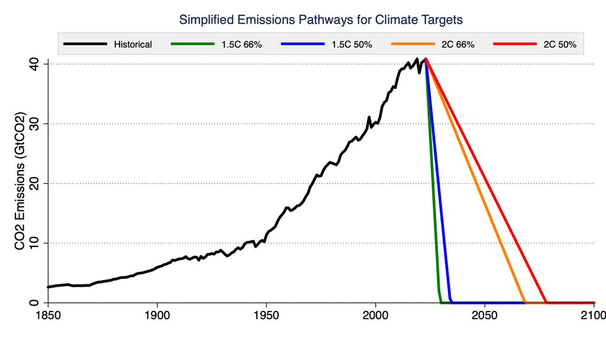

## Biodiversity at 1.5 vs 2 degrees

**Losing 50% of geographic range**

## Wind and Solar

[figure not shown]

## Solar Panels

[figure not shown]

## Electricity

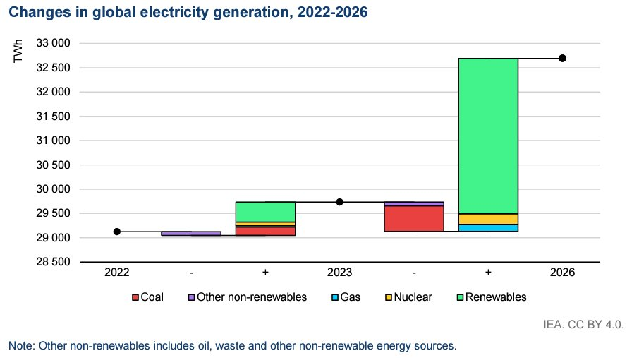

## Batteries

[figure not shown]

## Batteries

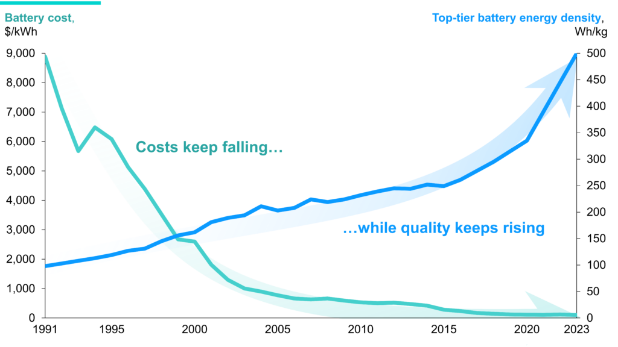

## Electric Vehicles

[figure not shown]

## Cross-National Variation

[figure not shown]

## China’s Growth

[figure not shown]

## Decoupling

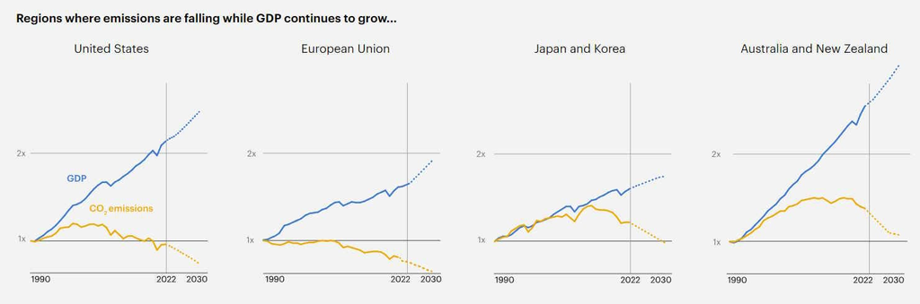

## Divergence

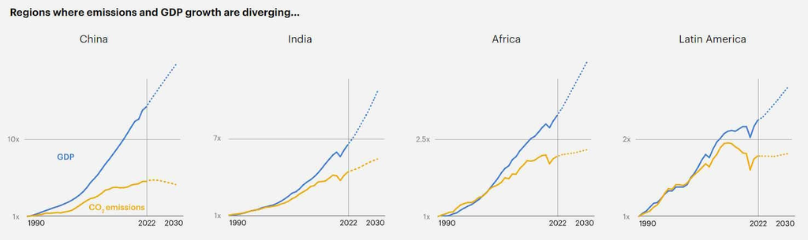

# Namrata (2023)

## Climate Adaptation

**Disproportionate vulnerability for developing countries**

- Higher mean temperatures
- Greater impact of temperature on output
- Long coastlines
- Lower incomes, smaller safety nets

## Three literatures

- Quantifying vulnerabilities
- Measuring adaptation
- Spatial linkages

## Climate Adaptation

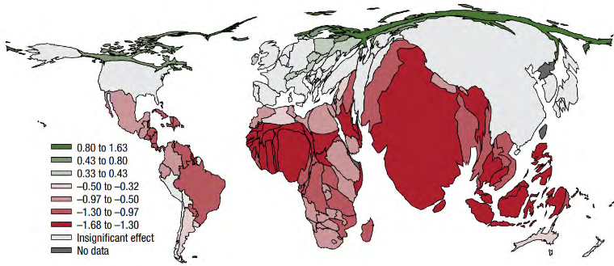

## Climate Adaptation

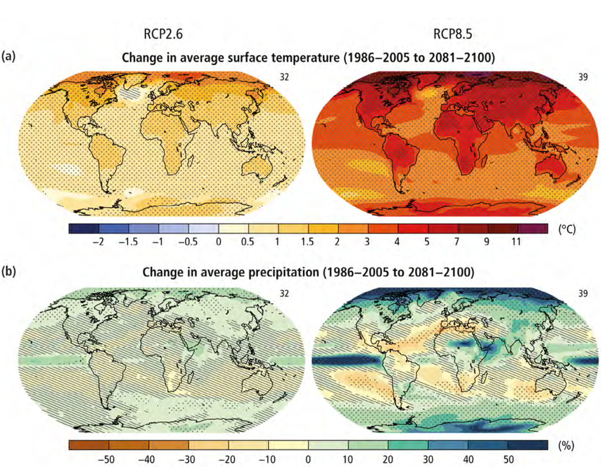

## Research Methods

- Panel data to find relationship between observed changes and output
- Project to future changes, assuming everything stays constant
- Problems:
  - Long-run adaptations
  - Short-run adaptations
  - Mechanisms?

## Research Methods

**Recent developments**

- Long-run changes (climate vs weather)
- Focus on expectations
- Experiments with adaptation

## Climate Adaptation

- Weather insurance
- Migration
- Cash transfers
- Credit
- New technology
- Infrastructure
- Safety nets

# O’Brien-Udry (2023)

# Albert at al. (2022)

## Measurement

- Reported natural disasters
- Moisture deficit relative to long-run average
- Agriculture yields
- Bank loans
- Migration and labor

## Findings

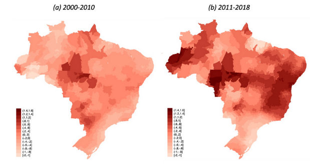

## Findings

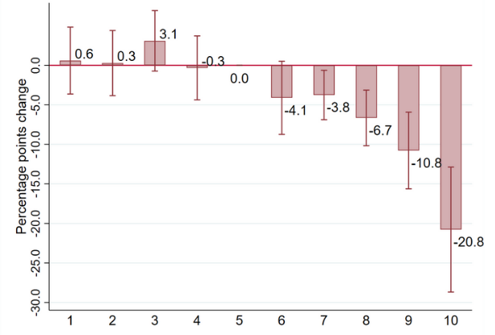

## Findings

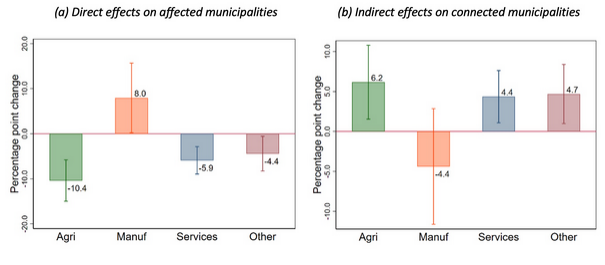

## Findings

https://carolina-torreblanca.github.io/psci3200-globaldev-main/